# IE360 Final RMD

## Autocorrelations of MCP’s

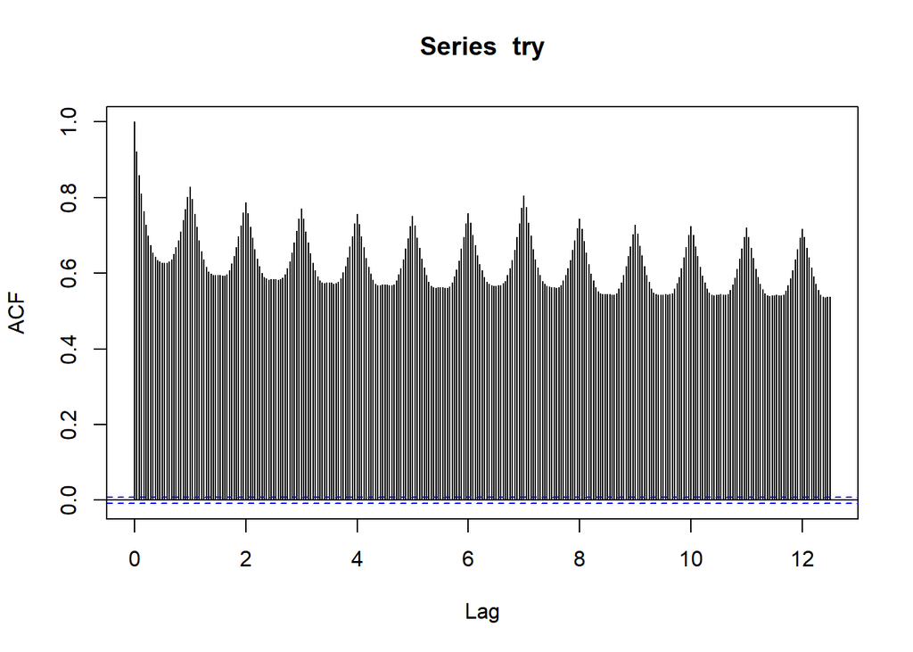

```r
acf(try,lag=300)
```

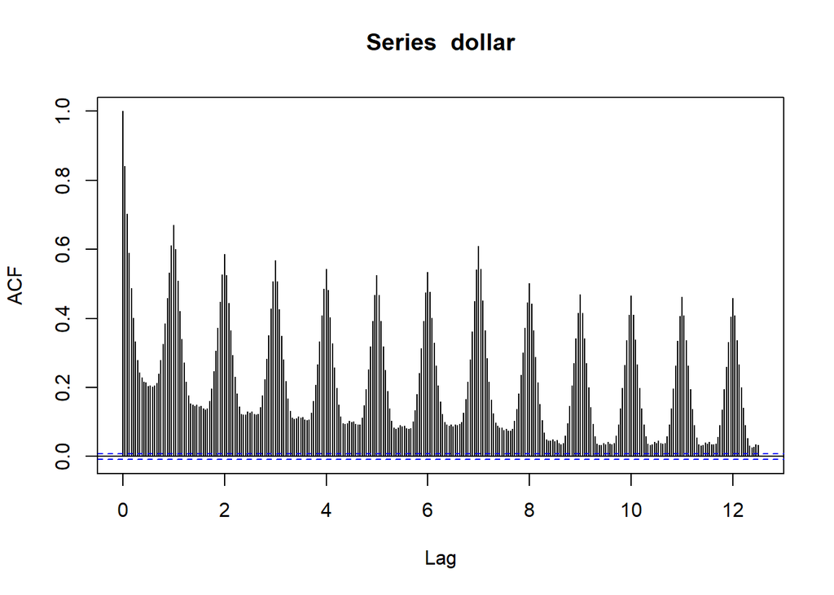

```r
acf(dollar,lag=300)
```

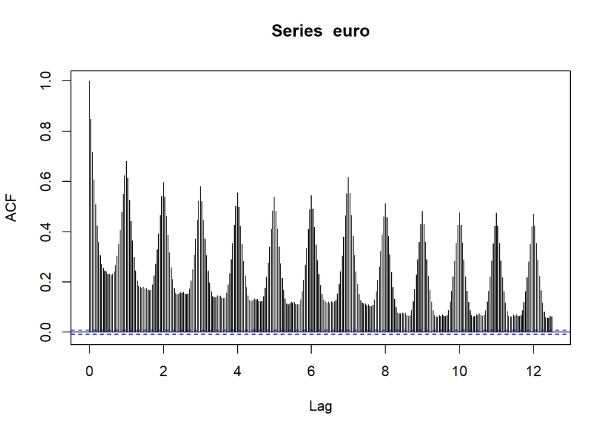

```r
acf(euro,lag=300)
```

As it is seen above, there is an obvious pattern in each acf plot of MCP’s. High autocorrelation at lag1, lag2 ,lag3 (integer values of lag variable) tells us there is daily seasonality (Frequancy was 24 in each). Moreover, it can be also concluded that there is relatively high autocorrelation at lag 7 weekly seasonality in addition to daily seasonality. This means each same hour of different days has similarity and each same day of different weeks has similarity too. For example, monday values are close to each other and 12:00 values are close to each other. These seasonalities holds for 3 types of MCP’s. ACF of Try has more autocorrelation which makes it less stationary, ACF of dollar has the least autocorrelation which makes it best option again, ACF of euro is somewhere in between try and dollar. As it is declared in previous part, we continue with dollar as mcp currency.

# Step 3

In this step, a forecasting will be done with time series analysis.

## Seasonality and Decomposition

Possibly type of seasonality is daily and weekly just as declared in the previous part.

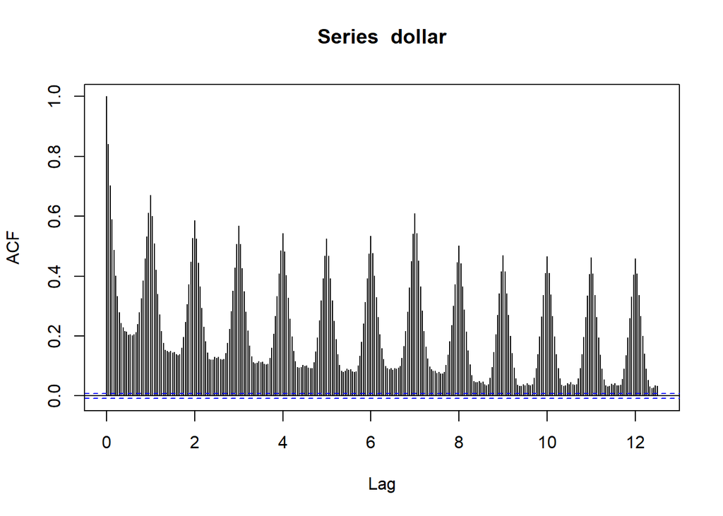

Multiplicative and additive time series decomposition is utilized in this chapter.

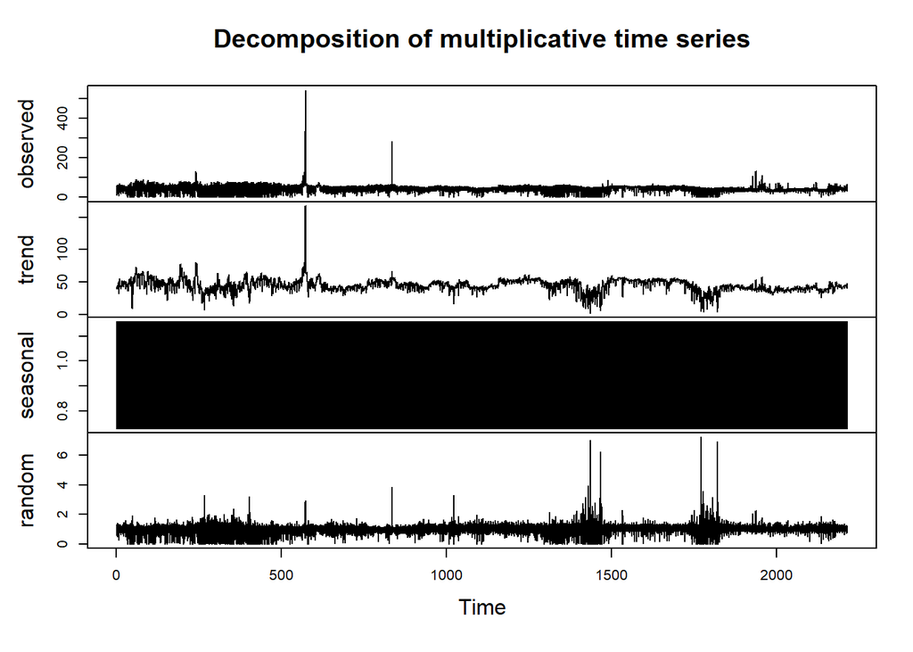

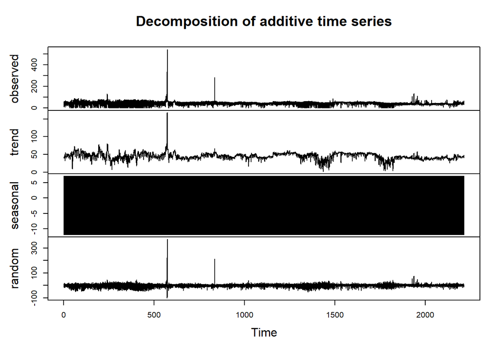

As it is seen in the plot, additive method gives better random values with more stable variance and mean. Both type of decomposition have outliers but in the multiplicative one, random value which is obtained from deseasonalization and detrend is not preferable compared to additive one.

Below part shows how decomposition is carried out.

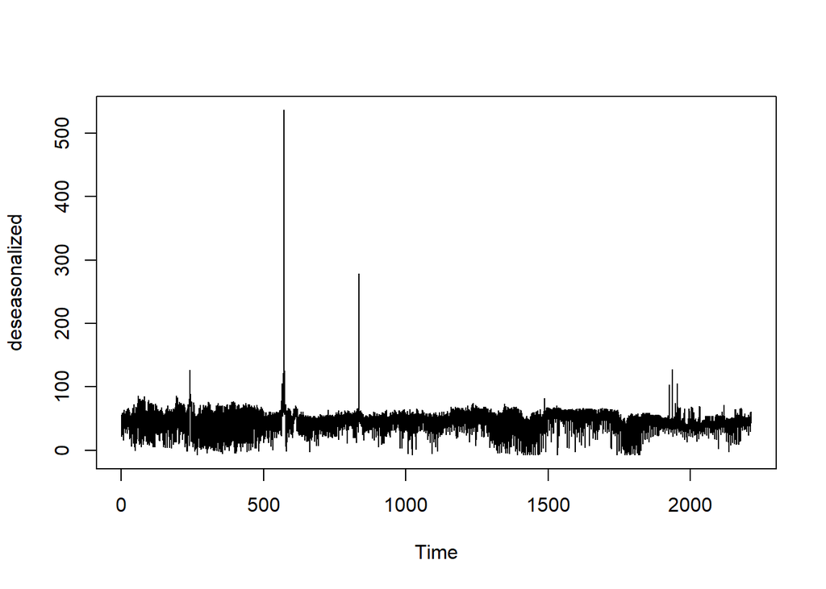

```r
dec<-decompose(dollar,type = "additive")
deseasonalized<-dollar-dec$seasonal
ts.plot(deseasonalized)
```

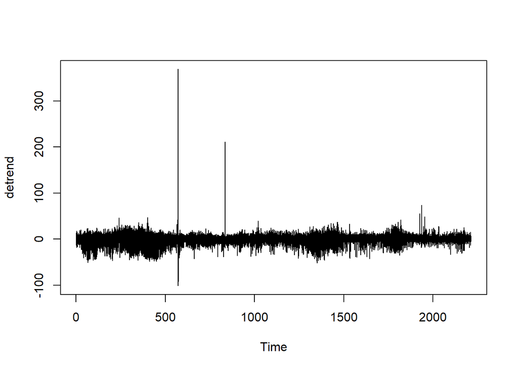

```r
detrend<-deseasonalized-dec$trend
ts.plot(detrend)
```

## Arima and Sarima Models

Code given below tries 3 manuel and 1 auto arima models.And fit3 is the best option due to low BIC and AIC (It is also simpler than auto arima).

```r
fit1=arima(dollar,order=c(1,0,0))
fit2=arima(diff(dollar,24),order=c(1,0,0))
fit3=arima(diff(dollar,24),order=c(1,0,0),seasonal=c(0,0,1))
arr=auto.arima(diff(dollar,24),max.p = 3,max.P = 1,max.q = 3,max.Q = 1,max.d = 1,max.D = 1)
BIC(fit1)
```

```
## [1] 368688
```

```r
BIC(fit2)
```

```
## [1] 373498.9
```

```r
BIC(fit3)
```

```
## [1] 346258.6
```

```r
BIC(arr)
```

```
## [1] 360042.8
```

```r
AIC(fit1)
```

```
## [1] 368661.4
```

```r
AIC(fit2)
```

```
## [1] 373472.2
```

```r
AIC(fit3)
```

```
## [1] 346223
```

```r
AIC(arr)
```

```
## [1] 359980.7
```

## Forecast

Below code gives forecast for test days.

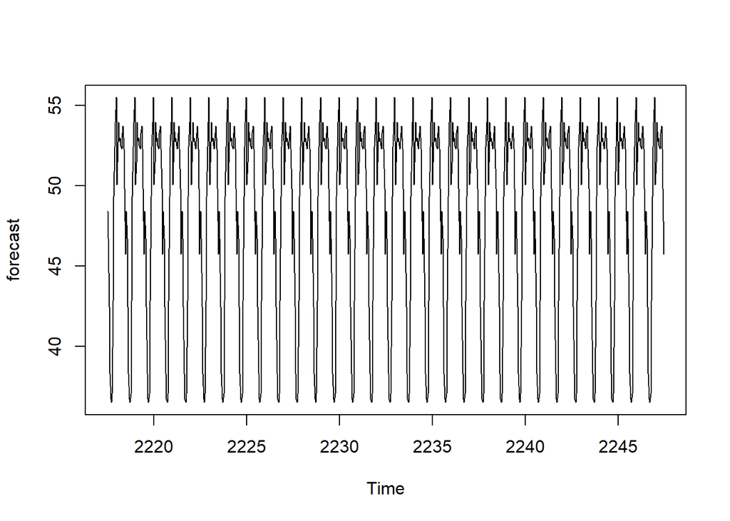

```r
predrand=predict(fit3,n.ahead=804)$pred
last_trend=tail(dec$trend[!is.na(dec$trend)],1)
seasval=dec$seasonal[85:888]
pred=seasval+last_trend+predrand
forecast=tail(pred,720)
ts.plot(forecast)
```

Below method calculates MAPE of forecast.

```r
accu(tail(data$mcp_dollars,720),forecast)
```

```
##        MAPE
## 1 0.1356153
```

# Step 4

In this step, a forecasting will be done with regression.

Necessary row and column operations are done to use on regressions later.

```r
data[,trend:=1:.N]
day=seq(1,7,by=1)
data=cbind(data,day)
hour=seq(0,23,by=1)
hour=cbind(data,hour)
```

```r
rg1 <- lm(mcp_dollars~trend, data = data)
summary(rg1)
```

```
##
## Call:
## lm(formula = mcp_dollars ~ trend, data = data)
##
## Residuals:
##    Min     1Q Median     3Q    Max
## -48.74  -6.75   1.12   9.77 495.02
##
## Coefficients:
##               Estimate Std. Error t value Pr(>|t|)
## (Intercept)  4.888e+01  1.232e-01  396.64   <2e-16 ***
## trend       -1.384e-04  4.018e-06  -34.43   <2e-16 ***
## ---
## Signif. codes:  0 '***' 0.001 '**' 0.01 '*' 0.05 '.' 0.1 ' ' 1
##
## Residual standard error: 14.2 on 53110 degrees of freedom
## Multiple R-squared:  0.02184,    Adjusted R-squared:  0.02182
## F-statistic:  1186 on 1 and 53110 DF,  p-value: < 2.2e-16
```

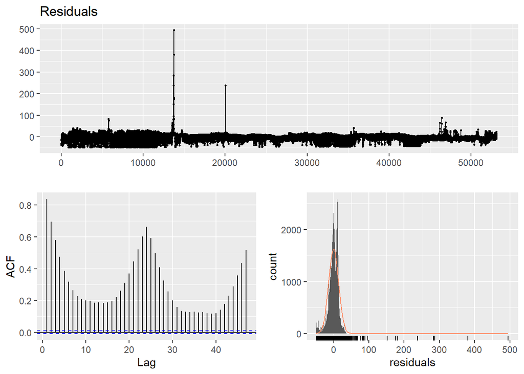

```
##
##  Breusch-Godfrey test for serial correlation of order up to 10
##
## data:  Residuals
## LM test = 37275, df = 10, p-value < 2.2e-16
```

```r
checkresiduals(rg1)
```

In this model, R-squared values seems really low but p-values of F statistics and trend variable are quite good. Residuals assumptions are not satisfied, mean is not around 0, variance does not seem stable and autocorrelation exists too much.

Seasonal components are added into model (seasonality has been identified in previous steps above (daily and weekly))

```r
rg2 <- lm(mcp_dollars~trend+as.factor(hour), data = data)
summary(rg2)
```

```
##
## Call:
## lm(formula = mcp_dollars ~ trend + as.factor(hour), data = data)
##
## Residuals:
##    Min     1Q Median     3Q    Max
## -54.78  -5.89   1.02   7.73 489.46
##
## Coefficients:
##                     Estimate Std. Error t value Pr(>|t|)
## (Intercept)        4.892e+01  2.902e-01 168.592  < 2e-16 ***
## trend             -1.385e-04  3.642e-06 -38.019  < 2e-16 ***
## as.factor(hour)1  -1.702e+00  3.869e-01  -4.400 1.08e-05 ***
## as.factor(hour)2  -5.967e+00  3.869e-01 -15.423  < 2e-16 ***
## as.factor(hour)3  -1.011e+01  3.869e-01 -26.137  < 2e-16 ***
## as.factor(hour)4  -1.169e+01  3.869e-01 -30.209  < 2e-16 ***
## as.factor(hour)5  -1.190e+01  3.869e-01 -30.746  < 2e-16 ***
## as.factor(hour)6  -1.134e+01  3.869e-01 -29.315  < 2e-16 ***
## as.factor(hour)7  -5.566e+00  3.869e-01 -14.385  < 2e-16 ***
## as.factor(hour)8   9.016e-01  3.869e-01   2.330 0.019787 *
## as.factor(hour)9   4.023e+00  3.869e-01  10.399  < 2e-16 ***
## as.factor(hour)10  5.522e+00  3.869e-01  14.272  < 2e-16 ***
## as.factor(hour)11  7.068e+00  3.869e-01  18.270  < 2e-16 ***
## as.factor(hour)12  1.652e+00  3.869e-01   4.270 1.96e-05 ***
## as.factor(hour)13  3.039e+00  3.869e-01   7.855 4.08e-15 ***
## as.factor(hour)14  5.519e+00  3.869e-01  14.266  < 2e-16 ***
## as.factor(hour)15  4.340e+00  3.869e-01  11.218  < 2e-16 ***
## as.factor(hour)16  4.555e+00  3.869e-01  11.773  < 2e-16 ***
## as.factor(hour)17  4.075e+00  3.869e-01  10.533  < 2e-16 ***
## as.factor(hour)18  3.887e+00  3.869e-01  10.048  < 2e-16 ***
## as.factor(hour)19  4.851e+00  3.869e-01  12.538  < 2e-16 ***
## as.factor(hour)20  5.295e+00  3.869e-01  13.686  < 2e-16 ***
## as.factor(hour)21  3.891e+00  3.869e-01  10.056  < 2e-16 ***
## as.factor(hour)22  1.405e+00  3.869e-01   3.630 0.000283 ***
## as.factor(hour)23 -2.674e+00  3.869e-01  -6.910 4.88e-12 ***
## ---
## Signif. codes:  0 '***' 0.001 '**' 0.01 '*' 0.05 '.' 0.1 ' ' 1
##
## Residual standard error: 12.87 on 53087 degrees of freedom
## Multiple R-squared:  0.1968, Adjusted R-squared:  0.1964
## F-statistic:   542 on 24 and 53087 DF,  p-value: < 2.2e-16
```

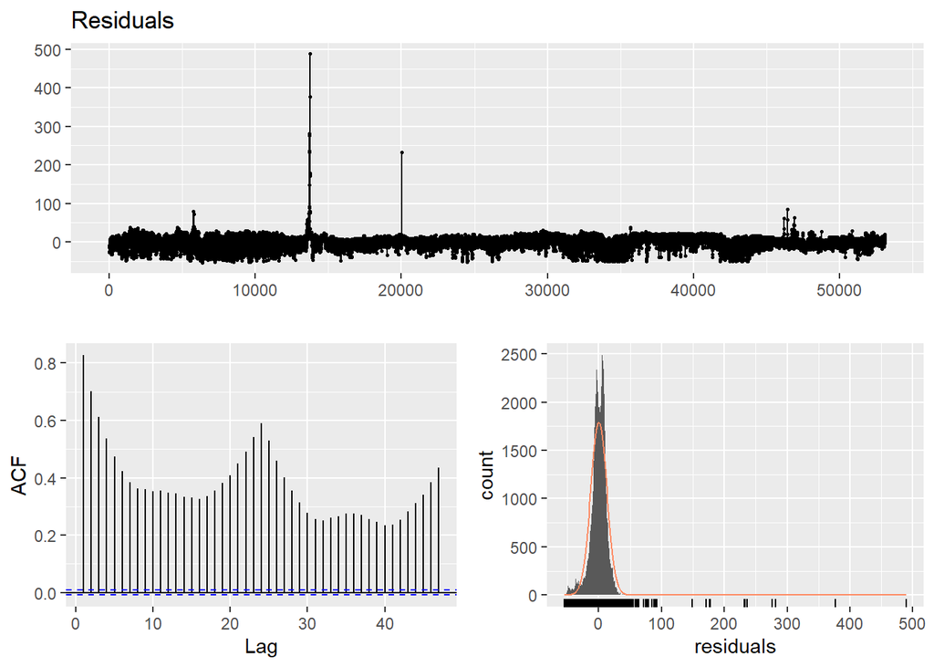

```
##
##  Breusch-Godfrey test for serial correlation of order up to 28
##
## data:  Residuals
## LM test = 38987, df = 28, p-value < 2.2e-16
```

```r
checkresiduals(rg2)
```

```r
rg3 <- lm(mcp_dollars~trend+as.factor(hour)+as.factor(day), data = data)
summary(rg3)
```

```
##
## Call:
## lm(formula = mcp_dollars ~ trend + as.factor(hour) + as.factor(day),
##     data = data)
##
## Residuals:
##    Min     1Q Median     3Q    Max
## -54.98  -5.90   1.02   7.74 489.70
##
## Coefficients:
##                     Estimate Std. Error t value Pr(>|t|)
## (Intercept)        4.893e+01  3.207e-01 152.549  < 2e-16 ***
## trend             -1.385e-04  3.642e-06 -38.023  < 2e-16 ***
## as.factor(hour)1  -1.702e+00  3.869e-01  -4.401 1.08e-05 ***
## as.factor(hour)2  -5.967e+00  3.869e-01 -15.425  < 2e-16 ***
## as.factor(hour)3  -1.011e+01  3.869e-01 -26.140  < 2e-16 ***
## as.factor(hour)4  -1.169e+01  3.869e-01 -30.211  < 2e-16 ***
## as.factor(hour)5  -1.190e+01  3.869e-01 -30.749  < 2e-16 ***
## as.factor(hour)6  -1.134e+01  3.869e-01 -29.317  < 2e-16 ***
## as.factor(hour)7  -5.566e+00  3.869e-01 -14.387  < 2e-16 ***
## as.factor(hour)8   9.015e-01  3.869e-01   2.330 0.019788 *
## as.factor(hour)9   4.023e+00  3.869e-01  10.399  < 2e-16 ***
## as.factor(hour)10  5.522e+00  3.869e-01  14.273  < 2e-16 ***
## as.factor(hour)11  7.069e+00  3.869e-01  18.272  < 2e-16 ***
## as.factor(hour)12  1.652e+00  3.869e-01   4.270 1.95e-05 ***
## as.factor(hour)13  3.039e+00  3.869e-01   7.856 4.05e-15 ***
## as.factor(hour)14  5.519e+00  3.869e-01  14.267  < 2e-16 ***
## as.factor(hour)15  4.340e+00  3.869e-01  11.218  < 2e-16 ***
## as.factor(hour)16  4.555e+00  3.869e-01  11.774  < 2e-16 ***
## as.factor(hour)17  4.075e+00  3.869e-01  10.534  < 2e-16 ***
## as.factor(hour)18  3.888e+00  3.869e-01  10.049  < 2e-16 ***
## as.factor(hour)19  4.851e+00  3.869e-01  12.539  < 2e-16 ***
## as.factor(hour)20  5.295e+00  3.869e-01  13.687  < 2e-16 ***
## as.factor(hour)21  3.891e+00  3.869e-01  10.057  < 2e-16 ***
## as.factor(hour)22  1.404e+00  3.869e-01   3.630 0.000283 ***
## as.factor(hour)23 -2.674e+00  3.869e-01  -6.911 4.85e-12 ***
## as.factor(day)2    1.889e-01  2.089e-01   0.904 0.365828
## as.factor(day)3    3.196e-01  2.089e-01   1.530 0.126131
## as.factor(day)4    1.346e-01  2.089e-01   0.644 0.519481
## as.factor(day)5   -3.084e-01  2.089e-01  -1.476 0.139864
## as.factor(day)6   -2.470e-01  2.089e-01  -1.182 0.237209
## as.factor(day)7   -1.457e-01  2.089e-01  -0.697 0.485674
## ---
## Signif. codes:  0 '***' 0.001 '**' 0.01 '*' 0.05 '.' 0.1 ' ' 1
##
## Residual standard error: 12.87 on 53081 degrees of freedom
## Multiple R-squared:  0.197,  Adjusted R-squared:  0.1966
## F-statistic: 434.1 on 30 and 53081 DF,  p-value: < 2.2e-16
```

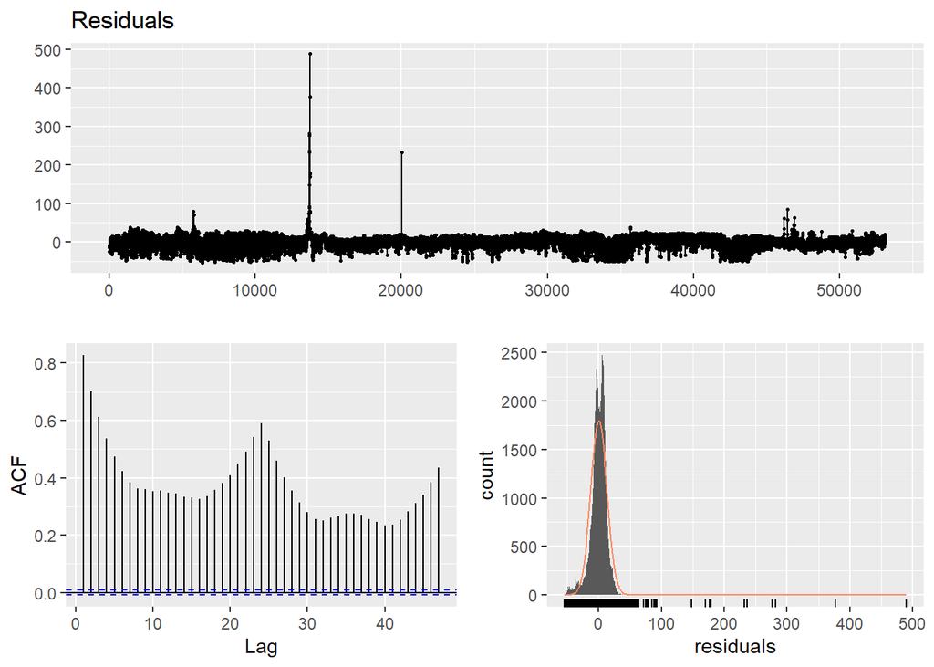

```
##
##  Breusch-Godfrey test for serial correlation of order up to 34
##
## data:  Residuals
## LM test = 39028, df = 34, p-value < 2.2e-16
```

```r
checkresiduals(rg3)
```

Furtherly, Correlation operation is used and it is decided to add load plan into model.

```r
cor(data$mcp_dollars,data$load_plan)
```

```
## [1] 0.5085458
```

```r
rg4 <- lm(mcp_dollars~trend+as.factor(hour)+as.factor(day)+load_plan, data = data)
summary(rg4)
```

```
##
## Call:
## lm(formula = mcp_dollars ~ trend + as.factor(hour) + as.factor(day) +
##     load_plan, data = data)
##
## Residuals:
##    Min     1Q Median     3Q    Max
## -51.05  -6.13   0.34   6.79 480.99
##
## Coefficients:
##                     Estimate Std. Error t value Pr(>|t|)
## (Intercept)        8.797e+00  4.695e-01  18.735  < 2e-16 ***
## trend             -2.349e-04  3.411e-06 -68.859  < 2e-16 ***
## as.factor(hour)1   4.318e-01  3.504e-01   1.232  0.21794
## as.factor(hour)2  -2.339e+00  3.515e-01  -6.655 2.87e-11 ***
## as.factor(hour)3  -5.489e+00  3.525e-01 -15.573  < 2e-16 ***
## as.factor(hour)4  -6.598e+00  3.530e-01 -18.692  < 2e-16 ***
## as.factor(hour)5  -6.556e+00  3.533e-01 -18.555  < 2e-16 ***
## as.factor(hour)6  -6.128e+00  3.532e-01 -17.353  < 2e-16 ***
## as.factor(hour)7  -2.112e+00  3.513e-01  -6.012 1.85e-09 ***
## as.factor(hour)8  -6.210e-01  3.502e-01  -1.773  0.07618 .
## as.factor(hour)9  -6.551e-01  3.525e-01  -1.858  0.06311 .
## as.factor(hour)10 -3.366e-01  3.540e-01  -0.951  0.34168
## as.factor(hour)11  4.027e-01  3.552e-01   1.134  0.25696
## as.factor(hour)12 -3.510e+00  3.531e-01  -9.940  < 2e-16 ***
## as.factor(hour)13 -2.704e+00  3.539e-01  -7.641 2.20e-14 ***
## as.factor(hour)14 -1.066e+00  3.551e-01  -3.003  0.00268 **
## as.factor(hour)15 -2.051e+00  3.548e-01  -5.780 7.51e-09 ***
## as.factor(hour)16 -2.018e+00  3.551e-01  -5.684 1.32e-08 ***
## as.factor(hour)17 -2.558e+00  3.552e-01  -7.204 5.94e-13 ***
## as.factor(hour)18 -2.539e+00  3.548e-01  -7.156 8.42e-13 ***
## as.factor(hour)19 -1.626e+00  3.549e-01  -4.582 4.62e-06 ***
## as.factor(hour)20 -1.013e+00  3.547e-01  -2.855  0.00431 **
## as.factor(hour)21 -1.572e+00  3.535e-01  -4.449 8.66e-06 ***
## as.factor(hour)22 -3.253e+00  3.525e-01  -9.228  < 2e-16 ***
## as.factor(hour)23 -5.340e+00  3.507e-01 -15.226  < 2e-16 ***
## as.factor(day)2    1.512e-01  1.890e-01   0.800  0.42347
## as.factor(day)3    2.174e-01  1.890e-01   1.151  0.24982
## as.factor(day)4    6.145e-02  1.890e-01   0.325  0.74502
## as.factor(day)5   -2.947e-01  1.890e-01  -1.560  0.11886
## as.factor(day)6   -1.511e-01  1.890e-01  -0.799  0.42404
## as.factor(day)7   -6.127e-02  1.890e-01  -0.324  0.74573
## load_plan          1.382e-03  1.271e-05 108.683  < 2e-16 ***
## ---
## Signif. codes:  0 '***' 0.001 '**' 0.01 '*' 0.05 '.' 0.1 ' ' 1
##
## Residual standard error: 11.64 on 53080 degrees of freedom
## Multiple R-squared:  0.3432, Adjusted R-squared:  0.3428
## F-statistic: 894.7 on 31 and 53080 DF,  p-value: < 2.2e-16
```

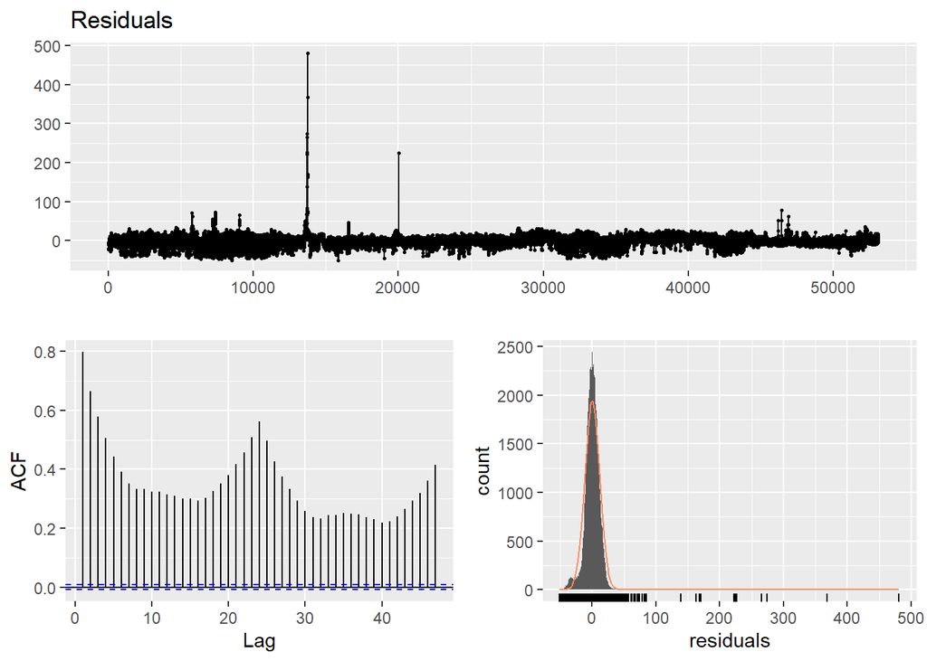

```
##
##  Breusch-Godfrey test for serial correlation of order up to 35
##
## data:  Residuals
## LM test = 36721, df = 35, p-value < 2.2e-16
```

```r
checkresiduals(rg4)
```

As it is seen from residuals table, residuals have close distribution to normal, around 0 mean and stable variance except for outliers. However, auto correlation is still too much.

This is final and the best model by adding lag1 to decrease autocorrelation.

```r
rg5 <- lm(mcp_dollars~trend+as.factor(hour)+as.factor(day)+load_plan+shift(mcp_dollars,1), data = data)
summary(rg5)
```

```
##
## Call:
## lm(formula = mcp_dollars ~ trend + as.factor(hour) + as.factor(day) +
##     load_plan + shift(mcp_dollars, 1), data = data)
##
## Residuals:
##     Min      1Q  Median      3Q     Max
## -166.16   -2.73    0.14    3.00  347.41
##
## Coefficients:
##                         Estimate Std. Error t value Pr(>|t|)
## (Intercept)            3.550e+00  2.889e-01  12.286  < 2e-16 ***
## trend                 -5.155e-05  2.184e-06 -23.602  < 2e-16 ***
## as.factor(hour)1      -3.325e+00  2.156e-01 -15.426  < 2e-16 ***
## as.factor(hour)2      -5.911e+00  2.162e-01 -27.345  < 2e-16 ***
## as.factor(hour)3      -6.477e+00  2.165e-01 -29.921  < 2e-16 ***
## as.factor(hour)4      -4.687e+00  2.169e-01 -21.612  < 2e-16 ***
## as.factor(hour)5      -3.600e+00  2.172e-01 -16.573  < 2e-16 ***
## as.factor(hour)6      -2.911e+00  2.171e-01 -13.406  < 2e-16 ***
## as.factor(hour)7       2.029e+00  2.162e-01   9.384  < 2e-16 ***
## as.factor(hour)8       2.822e+00  2.154e-01  13.105  < 2e-16 ***
## as.factor(hour)9       1.409e-01  2.165e-01   0.651   0.5152
## as.factor(hour)10     -1.083e+00  2.174e-01  -4.983 6.27e-07 ***
## as.factor(hour)11     -8.985e-01  2.182e-01  -4.118 3.82e-05 ***
## as.factor(hour)12     -7.189e+00  2.172e-01 -33.100  < 2e-16 ***
## as.factor(hour)13     -1.676e+00  2.173e-01  -7.710 1.28e-14 ***
## as.factor(hour)14     -4.775e-01  2.181e-01  -2.190   0.0286 *
## as.factor(hour)15     -3.563e+00  2.179e-01 -16.348  < 2e-16 ***
## as.factor(hour)16     -2.462e+00  2.181e-01 -11.291  < 2e-16 ***
## as.factor(hour)17     -3.125e+00  2.181e-01 -14.325  < 2e-16 ***
## as.factor(hour)18     -2.888e+00  2.179e-01 -13.252  < 2e-16 ***
## as.factor(hour)19     -1.788e+00  2.180e-01  -8.205 2.35e-16 ***
## as.factor(hour)20     -2.063e+00  2.178e-01  -9.472  < 2e-16 ***
## as.factor(hour)21     -3.624e+00  2.172e-01 -16.688  < 2e-16 ***
## as.factor(hour)22     -4.823e+00  2.165e-01 -22.274  < 2e-16 ***
## as.factor(hour)23     -6.494e+00  2.154e-01 -30.143  < 2e-16 ***
## as.factor(day)2        6.466e-02  1.160e-01   0.557   0.5773
## as.factor(day)3        3.208e-02  1.160e-01   0.277   0.7822
## as.factor(day)4       -2.483e-01  1.160e-01  -2.140   0.0324 *
## as.factor(day)5       -5.268e-01  1.160e-01  -4.540 5.63e-06 ***
## as.factor(day)6       -9.831e-02  1.160e-01  -0.847   0.3969
## as.factor(day)7       -4.799e-02  1.160e-01  -0.414   0.6792
## load_plan              3.145e-04  8.598e-06  36.574  < 2e-16 ***
## shift(mcp_dollars, 1)  7.862e-01  2.655e-03 296.145  < 2e-16 ***
## ---
## Signif. codes:  0 '***' 0.001 '**' 0.01 '*' 0.05 '.' 0.1 ' ' 1
##
## Residual standard error: 7.147 on 53078 degrees of freedom
##   (1 observation deleted due to missingness)
## Multiple R-squared:  0.7524, Adjusted R-squared:  0.7522
## F-statistic:  5039 on 32 and 53078 DF,  p-value: < 2.2e-16
```

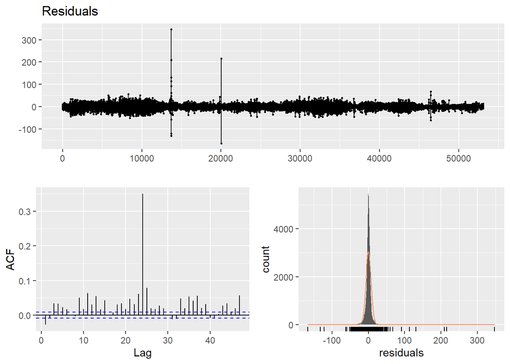

```
##
##  Breusch-Godfrey test for serial correlation of order up to 36
##
## data:  Residuals
## LM test = 9056.5, df = 36, p-value < 2.2e-16
```

```r
checkresiduals(rg5)
```

And this is the forecast values and its comparison to test values.

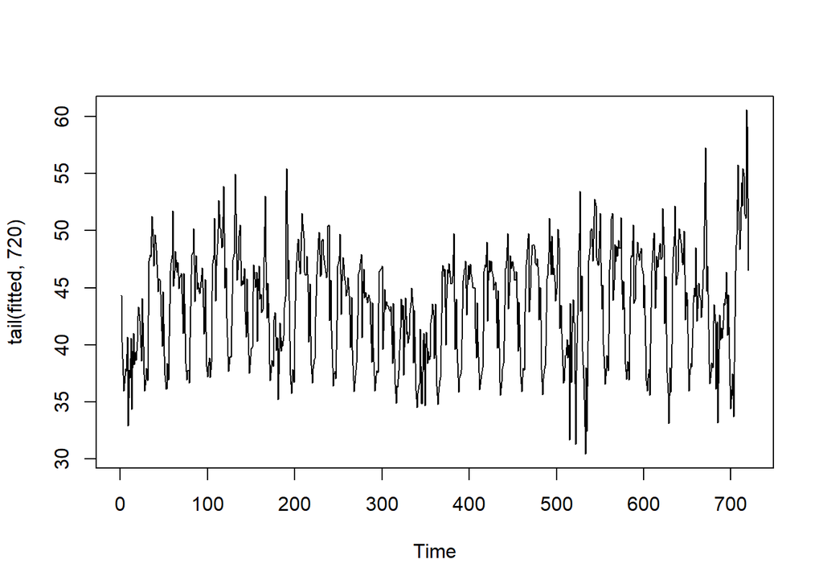

```r
fitted=predict(rg5)
ts.plot(tail(fitted,720))
```

```r
accu(tail(data$mcp_dollars,720),tail(fitted,720))
```

```
##        MAPE
## 1 0.0542962
```

# Conclusion

In this forecasting problem, 2 different methods has been utilised. According to MAPE values, regression model (MAPE=0.0542962) seems better than time series model (MAPE=0.1356153). In time series model, same trend value is used so it makes time series model less accurate. However, in regression model we could covered both seasonality and independent regressors succesfully in a better way.